# Practical Machine Learning project

Vachira Hunprasit

March 22, 2016

# Synopsis

This project is aimed to practice the skill obtained from the 4-week course of practical machine learning. The construction of predictive model is important in the variety of fields such as medicine and economics. In this project, the model building is built from the excercise data. The classification tree model was used to fulfil the objective. However, the initial model yeilded low accuracy. The ensemble model building, in this project random forest, is used to construct the model by voting the best tree model from many trees. The final model yeilded very high accuracy.

# Project objective

The objective of the project is to classify the paticipants who do excercise or not by using data from Jawbone Up, Nike FuelBand, and Fitbit device.

# Data Preparation

We download data from 2 data file which are for being traning and testing data, respectively

```r
##set working directory
setwd("C:\\VACHIRA\\Coursera\\Machinelearning\\Project")
#Load working data

training <- read.csv("train_set.csv", sep = ",", na.strings=c("NA",""))
testing <- read.csv("test_set.csv", sep = ",", na.strings=c("NA",""))
dim(training)
```

```
## [1] 19622   160
```

```r
dim(testing)
```

```
## [1]  20 160
```

Before we started the analyses, the follwing packagees were loaded

```r
library(caret)
library(tree)
library(rattle)
library(rpart)
library(randomForest)
```

# Cleaning data

We are working with traning data, then we have to clean the data by removing some column that contain a lot of Na. In this analysis, we used data which contained no missing value.

```r
NAindex <- apply(training,2,function(x) {sum(is.na(x))})
training <- training[,which(NAindex == 0)]
NAindex <- apply(testing,2,function(x) {sum(is.na(x))})
testing <- testing[,which(NAindex == 0)]
```

The training and testing data now consisted of 60 variables.

# Predictive model building

## Data partitioning

To solve the in sample variance, we partitioned the total data to be training set which used for model building and testing data which used for model performance evaluation. In this analysis, we used 75:25 ratio for partitioning

```r
set.seed(2016)
inTrain = createDataPartition(training$classe, p = 0.75, list = FALSE)
train.set = training[inTrain,]
test.set = training[-inTrain,]
```

We will build the predictive model on train.set data (14718 observations)

## Classification tree construction

We then constructed the decision tree which the output variable was classe and input variables were 59 varibles from the cleaning process.Since the X and name variable were not yeilded the prediction then we removed.

```r
train.set <- train.set[,-c(1:2)]
set.seed(2016)
modelFit <- tree(classe~. , data = train.set)
#plot(modelFit)
#text(modelFit)
summary(modelFit)
```

```
##
## Classification tree:
## tree(formula = classe ~ ., data = train.set)
## Variables actually used in tree construction:
##  [1] "cvtd_timestamp"       "num_window"           "raw_timestamp_part_1"
##  [4] "roll_belt"            "magnet_dumbbell_z"    "accel_dumbbell_y"
##  [7] "pitch_belt"           "roll_dumbbell"        "accel_belt_z"
## [10] "accel_dumbbell_x"
## Number of terminal nodes:  21
## Residual mean deviance:  0.4823 = 7088 / 14700
## Misclassification error rate: 0.08418 = 1239 / 14718
```

We evaluated the model performance

```r
predict.fit <- predict(modelFit, test.set, type = "class")
confusionMatrix(predict.fit, test.set$classe)
```

```
## Confusion Matrix and Statistics
##
##           Reference
## Prediction    A    B    C    D    E
##          A 1259  199    6    8    0
##          B  118  466  248   98    0
##          C   18  280  511   58    1
##          D    0    4   10  580   93
##          E    0    0   80   60  807
##
## Overall Statistics
##
##                Accuracy : 0.7388
##                  95% CI : (0.7262, 0.751)
##     No Information Rate : 0.2845
##     P-Value [Acc > NIR] : < 2.2e-16
##
##                   Kappa : 0.6688
##  Mcnemar's Test P-Value : NA
##
## Statistics by Class:
##
##                      Class: A Class: B Class: C Class: D Class: E
## Sensitivity            0.9025  0.49104   0.5977   0.7214   0.8957
## Specificity            0.9393  0.88268   0.9118   0.9739   0.9650
## Pos Pred Value         0.8553  0.50108   0.5887   0.8443   0.8522
## Neg Pred Value         0.9604  0.87846   0.9148   0.9469   0.9762
## Prevalence             0.2845  0.19352   0.1743   0.1639   0.1837
## Detection Rate         0.2567  0.09502   0.1042   0.1183   0.1646
## Detection Prevalence   0.3002  0.18964   0.1770   0.1401   0.1931
## Balanced Accuracy      0.9209  0.68686   0.7547   0.8476   0.9303
```

The model yeilded moderate accuracy rate (73.88%). Then we need to improve the accuracy rate by investigating where to stop pruning. We did cross validation to check the size of the tree which yielded lowest error rate.

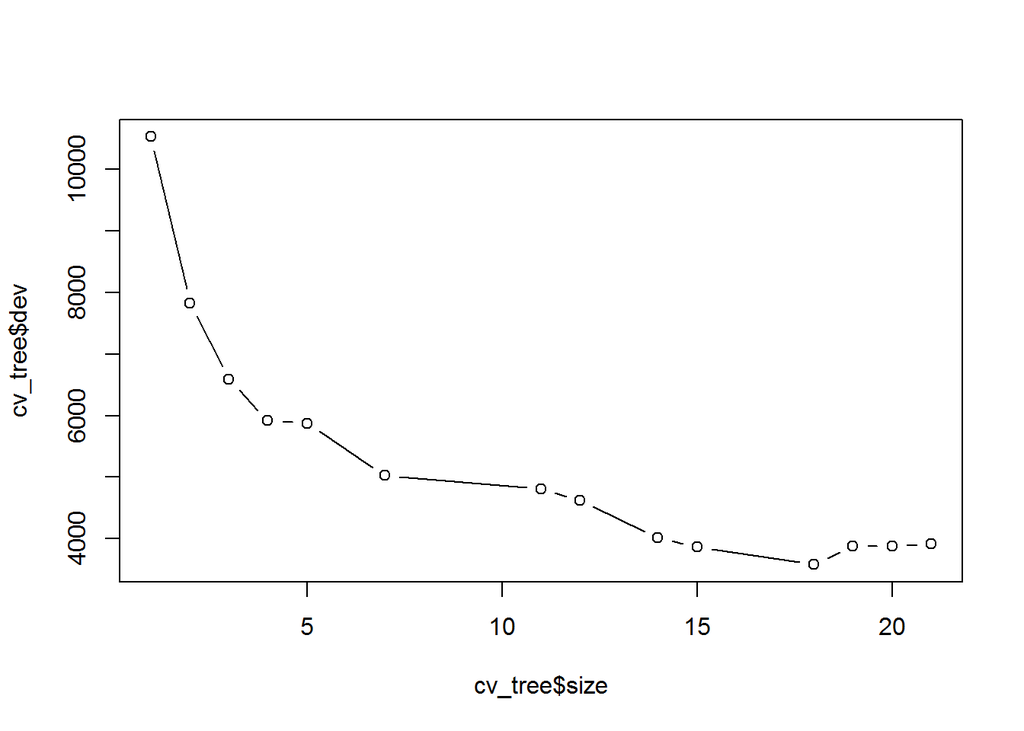

```r
set.seed(2016)
cv_tree <- cv.tree(modelFit, FUN = prune.misclass)
plot(cv_tree$size, cv_tree$dev, type = "b")
```

The tree size at 18 resulted the lowest error rate then we built new model and made the algorithm stopped at size 18.

```r
pruned_model <- prune.misclass(modelFit, best = 18)
summary(pruned_model)
```

```
##
## Classification tree:
## snip.tree(tree = modelFit, nodes = c(46L, 12L, 19L))
## Variables actually used in tree construction:
##  [1] "cvtd_timestamp"       "num_window"           "raw_timestamp_part_1"
##  [4] "roll_belt"            "magnet_dumbbell_z"    "accel_dumbbell_y"
##  [7] "pitch_belt"           "roll_dumbbell"        "accel_belt_z"
## [10] "accel_dumbbell_x"
## Number of terminal nodes:  18
## Residual mean deviance:  0.6145 = 9033 / 14700
## Misclassification error rate: 0.105 = 1546 / 14718
```

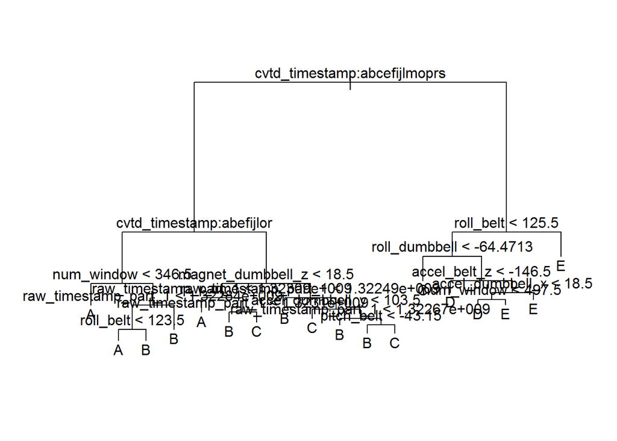

```r
plot(pruned_model)
text(pruned_model)
```

```r
predict.prune <- predict(pruned_model, test.set, type = "class")
confusionMatrix(predict.prune, test.set$classe)
```

```
## Confusion Matrix and Statistics
##
##           Reference
## Prediction    A    B    C    D    E
##          A 1259  199    6    8    0
##          B  134  605  282   98    0
##          C    2  141  557   68   42
##          D    0    4   10  580   93
##          E    0    0    0   50  766
##
## Overall Statistics
##
##                Accuracy : 0.7681
##                  95% CI : (0.7561, 0.7799)
##     No Information Rate : 0.2845
##     P-Value [Acc > NIR] : < 2.2e-16
##
##                   Kappa : 0.7058
##  Mcnemar's Test P-Value : NA
##
## Statistics by Class:
##
##                      Class: A Class: B Class: C Class: D Class: E
## Sensitivity            0.9025   0.6375   0.6515   0.7214   0.8502
## Specificity            0.9393   0.8700   0.9375   0.9739   0.9875
## Pos Pred Value         0.8553   0.5407   0.6877   0.8443   0.9387
## Neg Pred Value         0.9604   0.9091   0.9272   0.9469   0.9670
## Prevalence             0.2845   0.1935   0.1743   0.1639   0.1837
## Detection Rate         0.2567   0.1234   0.1136   0.1183   0.1562
## Detection Prevalence   0.3002   0.2282   0.1652   0.1401   0.1664
## Balanced Accuracy      0.9209   0.7538   0.7945   0.8476   0.9188
```

The accuracy rate was increased to 76.81% which was still a moderate accuracy.

## Ensemble tree model

We hoped to improve the performance of the classification model by cross validation, but the result was not satisfied. Then we construct multiple classification model called ensemble model which can improved the performace of the model. In this analysis, we used randomforest method.

```r
modRF <- randomForest(classe~ ., data = train.set)
print(modRF)
```

```
##
## Call:
##  randomForest(formula = classe ~ ., data = train.set)
##                Type of random forest: classification
##                      Number of trees: 500
## No. of variables tried at each split: 7
##
##         OOB estimate of  error rate: 0.09%
## Confusion matrix:
##      A    B    C    D    E  class.error
## A 4185    0    0    0    0 0.0000000000
## B    1 2846    1    0    0 0.0007022472
## C    0    5 2560    2    0 0.0027269186
## D    0    0    2 2409    1 0.0012437811
## E    0    0    0    1 2705 0.0003695492
```

```r
predict.RF <- predict(modRF, test.set, type = "class")
confusionMatrix(predict.RF,test.set$classe)
```

```
## Confusion Matrix and Statistics
##
##           Reference
## Prediction    A    B    C    D    E
##          A 1393    1    0    0    0
##          B    2  948    0    0    0
##          C    0    0  854    1    0
##          D    0    0    1  803    0
##          E    0    0    0    0  901
##
## Overall Statistics
##
##                Accuracy : 0.999
##                  95% CI : (0.9976, 0.9997)
##     No Information Rate : 0.2845
##     P-Value [Acc > NIR] : < 2.2e-16
##
##                   Kappa : 0.9987
##  Mcnemar's Test P-Value : NA
##
## Statistics by Class:
##
##                      Class: A Class: B Class: C Class: D Class: E
## Sensitivity            0.9986   0.9989   0.9988   0.9988   1.0000
## Specificity            0.9997   0.9995   0.9998   0.9998   1.0000
## Pos Pred Value         0.9993   0.9979   0.9988   0.9988   1.0000
## Neg Pred Value         0.9994   0.9997   0.9998   0.9998   1.0000
## Prevalence             0.2845   0.1935   0.1743   0.1639   0.1837
## Detection Rate         0.2841   0.1933   0.1741   0.1637   0.1837
## Detection Prevalence   0.2843   0.1937   0.1743   0.1639   0.1837
## Balanced Accuracy      0.9991   0.9992   0.9993   0.9993   1.0000
```

Surprisingly, the accuracy was increased to 99.9% which was very high. The model also have very high sensitivity where for class E, it was 100% sensitivity.